# Ejemplo 4

Fernando Rodríguez Fenoy

1/11/2021

# Ejemplo 4

Una empresa constructora ha obtenido un beneficio mayor de lo esperado este año y ha decidido dedicar una parte de éste a invertir en el negocio.

El jefe está barajando la posibilidad de dirigir ese dinero a contratar personal, invertir en publicidad o mejorar las infraestructuras de la empresa. Un dato a tener en cuenta es que se cree que se avecina una nueva crisis de la construcción y ésta echaría a perder las inversiones realizadas.

Veamos cuánto dinero se estima que ganarán en el próximo año

- Si la empresa invierte en publicidad: ganará 15000 euros si no hay crisis, y 5000 euros si la hay.
- Si la empresa contrata nuevo personal: ganará 20000 euros en caso de no darse la crisis, per perderá 5000 euros en caso de que sí.
- Si invierten en infraestructuras: ganará 10000 euros si no hay crisis, y 9000 si sí la hay.

¿Qué inversión le hará ganar más dinero a la empresa en el próximo año?

```r
y= c(15,5,
     20,-5,
     10,9)
tabla4 = crea.tablaX(y,numalternativas = 3, numestados = 2)
tabla4
```

```
##    e1 e2
## d1 15  5
## d2 20 -5
## d3 10  9
```

```r
sol4 = criterio.Todos(tabla4, favorable = TRUE)
sol4
```

```
##                   e1   e2 Wald Optimista Hurwicz Savage Laplace Punto Ideal
## d1                15    5    5        15     8.0      5    10.0       6.403
## d2                20   -5   -5        20     2.5     14     7.5      14.000
## d3                10    9    9        10     9.3     10     9.5      10.000
## iAlt.Opt (fav.) <NA> <NA>   d3        d2      d3     d1      d1          d1
```

- El *Criterio de Wald* nos dice que la alternativa óptima es invertir en infraestructuras.
- El *Criterio Optimista* se queda con la segunda alternativa: contratar nuevo personal.
- El *Criterio de Hurwicz* nos da como alternativa óptima invertir en infraestructuras.
- El *Criterio de Savage o Costes de oportunidad* nos elige la alternativa 1, es decir, invertir en publicidad*.*
- El *Criterio de Laplace* nos da como alternativa óptima invertir en publicidad*.*

Función creada por el grupo:

```r
Hurwicz.intervalos = function(tabla, favorable = TRUE){
  X = tabla # renombramos la tabla
  Altmin = apply(X,MARGIN=1,min)      # vector de minimos (por filas)
  Altmax = apply(X,MARGIN=1,max)      # vector de maximos (por filas)
  valfa = seq(from=0,to=1,by=0.05)    # vector de valores para alfa (entre 0 y 1)
  Hurw <- data.frame(Alt_opt = rep(0,length(valfa)),vHurwicz = rep(0,length(valfa)))

  #Alt_opt = rep(0,length(valfa))      # creamos el vector de decisiones (por el criterio de Hurwicz) para cada valor de alfa

  alfaCorte=c()                       # vector que contiene los valores de alfa donde cambian las decisiones
  for (i in 1:length(valfa)) {
    Opt <- criterio.Hurwicz(X, alfa = valfa[i], favorable)
    Hurw[i,] <-  rbind(Opt$AlternativaOptima[[1]],Opt$ValorOptimo) # obtenemos las alternativas para cada alfa
    Alt=c() # Este va a ser el Vector de las alternativas optimas para todos los alfa
    for (i in 1:dim(Hurw)[1]) {
      valrepetidos = duplicated(Hurw$Alt_opt) # Vector de TRUE/FALSE donde los FALSE son los elementos que se repiten
      if (isFALSE(valrepetidos[i])){
        Alt = c(Alt,Hurw$Alt_opt[i]) # Si es falso (si el valor se repite) lo almacenamos en el vector Alt
      }
    }
  }
  # Teniendo el vector de alternativas (Alt) buscamos los puntos de corte de las rectas asociadas a cada alternativa (beneficios)
  # Por ejemplo, la recta que sale de la alternativa a1 y a2 seria:
  #
  #               a1Max *alfa +(1-alfa)*a1Min = a2Max *alfa +(1-alfa)*a2Min
  #
  # Pasando todo a un  miembro e igualando a 0 nos queda:
  #
  #               alfa * (a1Max- a2Max - a1Min + a2Min) + a1Min -a2Min = 0
  #
  # Buscamos ahora los valores de alfa para los que se cortan las rectas asociadas a cada decision
  for (i in 1:(length(Alt)-1)){
    imax = as.numeric(Altmax[Alt[i]])      # maximo asociado a la decision i del vector Alt
    imax1 = as.numeric(Altmax[Alt[i+1]])   # maximo asociado a la decision i+1 del vector Alt
    imin = as.numeric(Altmin[Alt[i]])      # minimo asociado a la decision i del vector Alt
    imin1 = as.numeric(Altmin[Alt[i+1]])   # minimo asociado a la decision i+1 del vector Alt
    if (favorable){
      pCorte = function(alfa) {alfa * (imax-imax1-imin+imin1)+imin-imin1}
      alfaC = uniroot(pCorte, interval = c(0,1))$root[[1]] # Buscamos los 0 para cada funcion
      alfaCorte[i] = alfaC  # Almacenamos los valores de alfa para los que las rectas se cortan en alfaCorte
    } else {
      # Para el caso de costes (alternativas a1 y a2):
      #
      #               a1Max *(1-alfa) +alfa*a1Min = a2Max *(1-alfa) +alfa*a2Min
      #
      # Pasando todo a un  miembro e igualando a 0 nos queda:
      #
      #               alfa * (a1Min- a2Min - a1Max + a2Max) + a1Max -a2Max = 0
      #
      pCorte = function(alfa) {alfa * (imin-imin1-imax+imax1)+imax-imax1}
      alfaC = uniroot(pCorte, interval = c(0,1))$root[[1]] # Buscamos los 0 para cada funcion
      alfaCorte[i] = alfaC  # Almacenamos los valores de alfa para los que las rectas se cortan en alfaCorte
    }
    print(paste("El valores de alfa que determina los intervalos dónde cambian las alternativas óptimas es:",alfaCorte[i]))

  }

  x0=0;x1=1;
  y0 = min(Altmin);
  y1 = max(Altmax);
  rg = y1-y0;
  y0=y0-0.1*rg;y1=y1+0.1*rg;
  plot(c(x0,x1), c(y0,y1), type = "n", xlab = "alpha", ylab = "Criterio Hurwicz");
  nn = length(Altmin);
  colores = rainbow(nn) #aquí es donde estaba el fallo, por lo que salían todas las lineas azules.
  abline(v=0);
  abline(v=1);
  if (favorable) {
    for (i in 1:nn) {
      aa = Altmin[i];
      bb = (Altmax[i] - Altmin[i]);
      abline(a=aa,b=bb,col=colores[i]);
    }
  } else {
    for (i in 1:nn) {
      aa = Altmax[i];
      bb = (Altmin[i] - Altmax[i]);
      abline(a=aa,b=bb,col=colores[i]);
    }
  }

  lines(valfa,Hurw$vHurwicz,col="green",lty=3,lwd=3)
  abline(v = alfaCorte, col="red")

  if (favorable) {
    legend("bottomright",legend=rownames(X),fill=colores,inset=0.05) #leyendas añadidas
    title("Criterio de Hurwicz (favorable - línea discontinua)")
  } else {
    legend("topright",legend=rownames(X),fill=colores,inset=0.05) #leyendas añadidas
    title("Criterio de Hurwicz (desfavorable - línea discontinua)")
  }

  alfaCorte = round(alfaCorte, 3)
  if (length(alfaCorte)==1){
    Int1=paste("(",0,",",alfaCorte,")")
    Int2=paste("(",alfaCorte,",",1,")")
    Soluciones = cbind(c(Int1,Int2),c(Alt[1],Alt[2]))
  } else {
    Int0=paste("(",0,",",alfaCorte[1],")")
    Int1=paste("(",alfaCorte[length(alfaCorte)],",",1,")")
    Int = ""
    Soluciones= c(Int0, Alt[1])
    for (i in 1:(length(alfaCorte)-1)){
      Int[i] = paste("(",alfaCorte[i],",",alfaCorte[i+1],")")
      Soluciones = rbind(Soluciones,c(Int[i],Alt[i+1]))
    }
    Soluciones = rbind(Soluciones,c(Int1,Alt[length(Alt)]))
  }
  colnames(Soluciones)=c("Intervalo","Alternativa")

  resultados = list();
  resultados$AltOptimas = Alt;
  resultados$PuntosDeCorte = alfaCorte;
  resultados$IntervalosAlfa = Soluciones;
  return(resultados)
}
```

```r
Hurwicz.intervalos(tabla4, favorable = TRUE)
```

```
## [1] "El valores de alfa que determina los intervalos dónde cambian las alternativas óptimas es: 0.444444444444444"
## [1] "El valores de alfa que determina los intervalos dónde cambian las alternativas óptimas es: 0.666666666666667"
```

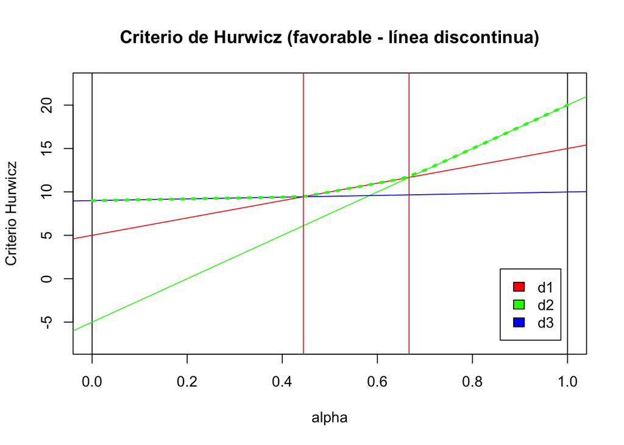

```
## $AltOptimas
## [1] 3 1 2
##
## $PuntosDeCorte
## [1] 0.444 0.667
##
## $IntervalosAlfa
##            Intervalo           Alternativa
## Soluciones "( 0 , 0.444 )"     "3"
##            "( 0.444 , 0.667 )" "1"
##            "( 0.667 , 1 )"     "2"
```

Por tanto, para un valor de alfa=0.5:

```r
criterio.Hurwicz.General(tabla4, alfa = 0.5, favorable = TRUE)
```

```
## $criterio
## [1] "Hurwicz"
##
## $alfa
## [1] 0.5
##
## $metodo
## [1] "favorable"
##
## $tablaX
##    e1 e2
## d1 15  5
## d2 20 -5
## d3 10  9
##
## $ValorAlternativas
##   d1   d2   d3
## 10.0  7.5  9.5
##
## $ValorOptimo
## [1] 10
##
## $AlternativaOptima
## d1
##  1
```

Solución: para un alfa = 0.5, el método de Hurwicz nos dice que la alternativa óptima sería invertir en publicidad.